# Data Science in Practice with Python

### Step 5 - Building the model (Linear Regression)

Sources:

- http://www.statsmodels.org/stable/
- http://www.statsmodels.org/stable/examples/notebooks/generated/ols.html

```python
import statsmodels.formula.api as smf
```

```python
m = smf.ols(formula='price_doc ~ num_room', data=X).fit()
print (m.summary())
```

```
                            OLS Regression Results
==============================================================================
Dep. Variable:              price_doc   R-squared:                       0.165
Model:                            OLS   Adj. R-squared:                  0.165
Method:                 Least Squares   F-statistic:                     4414.
Date:                Thu, 06 Jul 2017   Prob (F-statistic):               0.00
Time:                        23:15:22   Log-Likelihood:                -17952.
No. Observations:               22413   AIC:                         3.591e+04
Df Residuals:                   22411   BIC:                         3.592e+04
Df Model:                           1
Covariance Type:            nonrobust
==============================================================================
                 coef    std err          t      P>|t|      [95.0% Conf. Int.]
------------------------------------------------------------------------------
Intercept     15.1075      0.009   1680.699      0.000        15.090    15.125
num_room       0.2858      0.004     66.441      0.000         0.277     0.294
==============================================================================
Omnibus:                     5889.417   Durbin-Watson:                   1.965
Prob(Omnibus):                  0.000   Jarque-Bera (JB):            22491.105
Skew:                          -1.273   Prob(JB):                         0.00
Kurtosis:                       7.196   Cond. No.                         6.25
==============================================================================

Warnings:
[1] Standard Errors assume that the covariance matrix of the errors is correctly specified.
```

```python
m = smf.ols(formula='price_doc ~ full_sq', data=X).fit()
print (m.summary())
```

```
                            OLS Regression Results
==============================================================================
Dep. Variable:              price_doc   R-squared:                       0.231
Model:                            OLS   Adj. R-squared:                  0.231
Method:                 Least Squares   F-statistic:                     6744.
Date:                Thu, 06 Jul 2017   Prob (F-statistic):               0.00
Time:                        23:15:22   Log-Likelihood:                -17019.
No. Observations:               22413   AIC:                         3.404e+04
Df Residuals:                   22411   BIC:                         3.406e+04
Df Model:                           1
Covariance Type:            nonrobust
==============================================================================
                 coef    std err          t      P>|t|      [95.0% Conf. Int.]
------------------------------------------------------------------------------
Intercept     14.9549      0.009   1626.405      0.000        14.937    14.973
full_sq        0.0129      0.000     82.123      0.000         0.013     0.013
==============================================================================
Omnibus:                     9744.064   Durbin-Watson:                   1.986
Prob(Omnibus):                  0.000   Jarque-Bera (JB):            92445.147
Skew:                          -1.844   Prob(JB):                         0.00
Kurtosis:                      12.240   Cond. No.                         156.
==============================================================================

Warnings:
[1] Standard Errors assume that the covariance matrix of the errors is correctly specified.
```

```python
m = smf.ols(formula='price_doc ~ full_sq + num_room + build_year + product_type', data=X).fit()
print (m.summary())
```

```
                            OLS Regression Results
==============================================================================
Dep. Variable:              price_doc   R-squared:                       0.259
Model:                            OLS   Adj. R-squared:                  0.259
Method:                 Least Squares   F-statistic:                     1963.
Date:                Thu, 06 Jul 2017   Prob (F-statistic):               0.00
Time:                        23:15:23   Log-Likelihood:                -16601.
No. Observations:               22413   AIC:                         3.321e+04
Df Residuals:                   22408   BIC:                         3.325e+04
Df Model:                           4
Covariance Type:            nonrobust
================================================================================
                   coef    std err          t      P>|t|      [95.0% Conf. Int.]
--------------------------------------------------------------------------------
Intercept       15.0911      0.013   1122.944      0.000        15.065    15.117
full_sq          0.0113      0.000     53.166      0.000         0.011     0.012
num_room         0.0822      0.006     14.802      0.000         0.071     0.093
build_year      -0.0002      0.001     -0.436      0.663        -0.001     0.001
product_type    -0.1525      0.007    -20.763      0.000        -0.167    -0.138
==============================================================================
Omnibus:                    10089.173   Durbin-Watson:                   1.988
Prob(Omnibus):                  0.000   Jarque-Bera (JB):            76991.262
Skew:                          -2.007   Prob(JB):                         0.00
Kurtosis:                      11.144   Cond. No.                         255.
==============================================================================

Warnings:
[1] Standard Errors assume that the covariance matrix of the errors is correctly specified.
```

```python
from sklearn.model_selection import train_test_split
from sklearn import linear_model
from sklearn.metrics import mean_squared_error
```

Let’s partition the data and start modeling. We will use the train_test_split() function from [scikit-learn](http://scikit-learn.org/stable/modules/generated/sklearn.model_selection.train_test_split.html) to create a training set and a hold-out set. Partitioning the data in this way allows us to evaluate how our model might perform on data that it has never seen before. If we train the model on all of the test data, it will be difficult to tell if overfitting has taken place.

train_test_split() returns four objects:

- Z_train is the subset of our features used for training.
- Z_test is the subset which will be our ‘hold-out’ set - what we’ll use to test the model.
- y_train is the target variable 'price_doc' which corresponds to Z_train.
- y_test is the target variable 'price_doc' which corresponds to Z_test.

```python
y = X['price_doc']
Z = X.drop(['num_room', 'product_type', 'build_year','price_doc'], axis=1)

Z_train, Z_test, y_train, y_test = train_test_split(Z, y, random_state=45, test_size=.50)
```

```python
lr = linear_model.LinearRegression()
model = lr.fit(Z_train, y_train)
```

Now, we want to evaluate the performance of the model. Each competition might evaluate the submissions differently. In this competition, Kaggle will evaluate our submission using root-mean-squared-error (RMSE). We’ll also look at The r-squared value. The r-squared value is a measure of how close the data are to the fitted regression line. It takes a value between 0 and 1, 1 meaning that all of the variance in the target is explained by the data. In general, a higher r-squared value means a better fit.

The model.score() method returns the r-squared value by default.

```python
print("R² Score => ", model.score(Z_test, y_test))
```

```
R² Score =>  0.217740153499
```

```python
predictions = model.predict(Z_test)
```

```python
print("RMSE => ", mean_squared_error(y_test, predictions))
```

[output not shown]

```
<function matplotlib.pyplot.show>
```

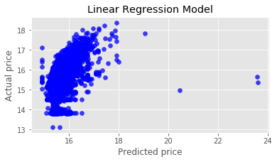

```python
actual_values = y_test
plt.scatter(predictions, actual_values, alpha=.75, color='b')  # alpha helps to show overlapping data
plt.xlabel('Predicted price')
plt.ylabel('Actual price')
plt.title('Linear Regression Model')
plt.show
```

**Ridge Regularization (Linear least squares with L2 regularization)**

This model solves a regression model where the loss function is the linear least squares function and regularization is given by the L2-norm. Also known as Ridge Regression or Tikhonov regularization. This estimator has built-in support for multi-variate regression (i.e., when y is a 2d-array of shape [n_samples, n_targets]).

Source: http://scikit-learn.org/stable/modules/generated/sklearn.linear_model.Ridge.html

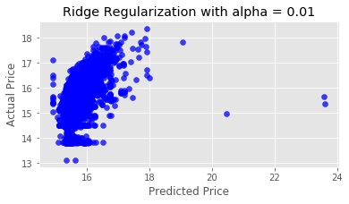

```
--------------------------------------------------
R² =>  0.217740153615
RMSE =>  0.272118677523
--------------------------------------------------
```

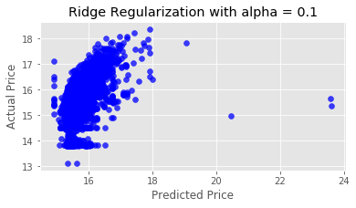

```
--------------------------------------------------
R² =>  0.217740154658
RMSE =>  0.27211867716
--------------------------------------------------
```

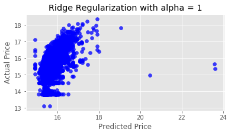

```
--------------------------------------------------
R² =>  0.21774016509
RMSE =>  0.272118673531
--------------------------------------------------
```

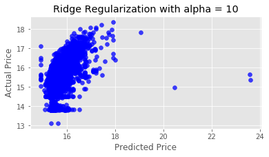

```
--------------------------------------------------
R² =>  0.217740269409
RMSE =>  0.272118637242
--------------------------------------------------
```

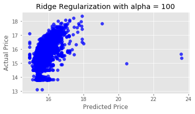

```
--------------------------------------------------
R² =>  0.217741312481
RMSE =>  0.272118274397
--------------------------------------------------
```

```python
for i in range (-2, 3):
    alpha = 10**i
    rm = linear_model.Ridge(alpha=alpha)
    ridge_model = rm.fit(Z_train, y_train)
    preds_ridge = ridge_model.predict(Z_test)

    plt.scatter(preds_ridge, actual_values, alpha=.75, color='b')
    plt.xlabel('Predicted Price')
    plt.ylabel('Actual Price')
    plt.title('Ridge Regularization with alpha = {}'.format(alpha))
    plt.show()
    print('-' * 50)
    print('R² => ', ridge_model.score(Z_test, y_test))
    print('RMSE => ', mean_squared_error(y_test, preds_ridge))
    print('-' * 50)
```

### Step 6 - Making a submission

```python
data = test.select_dtypes(include=[np.number]).interpolate().dropna()
data.shape
```

```
(7660, 275)
```

```python
# new_test = data[['id', 'full_sq', 'num_room']].fillna(value=1)
new_test = data[['id', 'full_sq', 'num_room']]
new_test.shape
```

```
(7660, 3)
```

```python
prodtype = {
'Investment': 1,
'OwnerOccupier': 2,
'NaN':1
}
new_test['product_type'] = test['product_type'].map(prodtype).fillna(value=1)
new_test.shape
```

```
(7660, 4)
```

```python
def calcbuildyear(series):
    if series['build_year'] <= 1:
        return 1
    elif series['build_year'] > 1:
        return 2017/series['build_year']
    else:
        return 1
```

```python
# new_test['build_year'] = data.apply(calcbuildyear, axis=1).fillna(value=1)
new_test['build_year'] = data.apply(calcbuildyear, axis=1)
new_test.shape
```

```
(7660, 5)
```

```python
# We will create a new dataframe with some outliers removed.
df = new_test[new_test['full_sq'] > 0]
df.shape
```

```
(7659, 5)
```

```python
sum(df.isnull().sum() != 0)
```

```
0
```

```python
submission = pd.DataFrame()
submission['id'] = df['id']
submission.shape
```

```
(7659, 1)
```

```python
Z = df.drop(['id','num_room', 'product_type', 'build_year'], axis=1)
```

```python
predictions = model.predict(Z)
```

```python
final_predictions = np.exp(predictions)
```

```python
print(">> Original predictions are:\n", predictions[:5], "\n")
print(">> Final predictions are:\n", final_predictions[:5])
```

```
>> Original predictions are:
 [ 15.46314328  15.76748615  15.45631945  15.57136924  15.43994225]

>> Final predictions are:
 [ 5194668.02181842  7042587.14052995  5159341.1530575   5788416.02423529
  5075533.75477477]
```

```python
submission['price_doc'] = final_predictions
submission.head()
```

|  | id | price_doc |
| --- | --- | --- |
| 2 | 30476 | 5.194668e+06 |
| 3 | 30477 | 7.042587e+06 |
| 4 | 30478 | 5.159341e+06 |
| 5 | 30479 | 5.788416e+06 |
| 6 | 30480 | 5.075534e+06 |

```python
submission.to_csv(path+'submission1.csv', index=False)
```

### Next steps

You can extend this tutorial and improve your results by:

- Working with and transforming other features in the training set
- Experimenting with different modeling techniques, such as Random Forest Regressors or Gradient Boosting
- Using ensembling models

We created a set of categorical features called categoricals that were not all included in the final model. Go back and try to include these features. There are other methods that might help with categorical data, notably the pd.get_dummies() method. After working on these features, repeat the transformations for the test data and make another submission.

Working on models and participating in Kaggle competitions can be an iterative process – it’s important to experiment with new ideas, learn about the data, and test newer models and techniques.

With these tools, you can build upon your work and improve your results.

Good luck!

If you want contact me to explain some doubts, make suggestions or criticals...or to know my services - please send me an e-mail: laercio.serra@gmail.com, or visit my website for more details, in: http://lserra.datafresh.com.br